# Projekt zaliczeniowy SAD

Daniel Pysz 449010

# Zadanie 1 - Eksploracja

Wczytanie danych:

```r
set.seed(449010)
train_x <- read.csv("/home/pysz/X_train.csv")
train_y <- read.csv("/home/pysz/y_train.csv")
test_x <- read.csv("/home/pysz/X_test.csv")
```

Sprawdzenie czy dane są kompletne:

```r
sum(is.na(train_x))
```

```
## [1] 0
```

```r
sum(is.na(train_y))
```

```
## [1] 0
```

```r
sum(is.na(test_x))
```

```
## [1] 0
```

Określenie typu wszystkich zmiennych:

```r
for (i in length(train_x)){
     type <- typeof(train_x[,i])
     if (type != "double"){
         print(typeof[train_x[,i]])
     }
}
for (i in length(train_y)){
     type <- typeof(train_y[,i])
     if (type != "double"){
         print(typeof[train_y[,i]])
     }
}
for (i in length(test_x)){
     type <- typeof(test_x[,i])
     if (type != "double"){
         print(typeof[test_x[,i]])
     }
}
```

Podstawowe statystyki opisowe zmiennej objaśnianej:

```r
summary(train_y)
```

```
##       CD36
##  Min.   :0.0000
##  1st Qu.:0.0000
##  Median :0.5437
##  Mean   :1.0862
##  3rd Qu.:1.9612
##  Max.   :5.1264
```

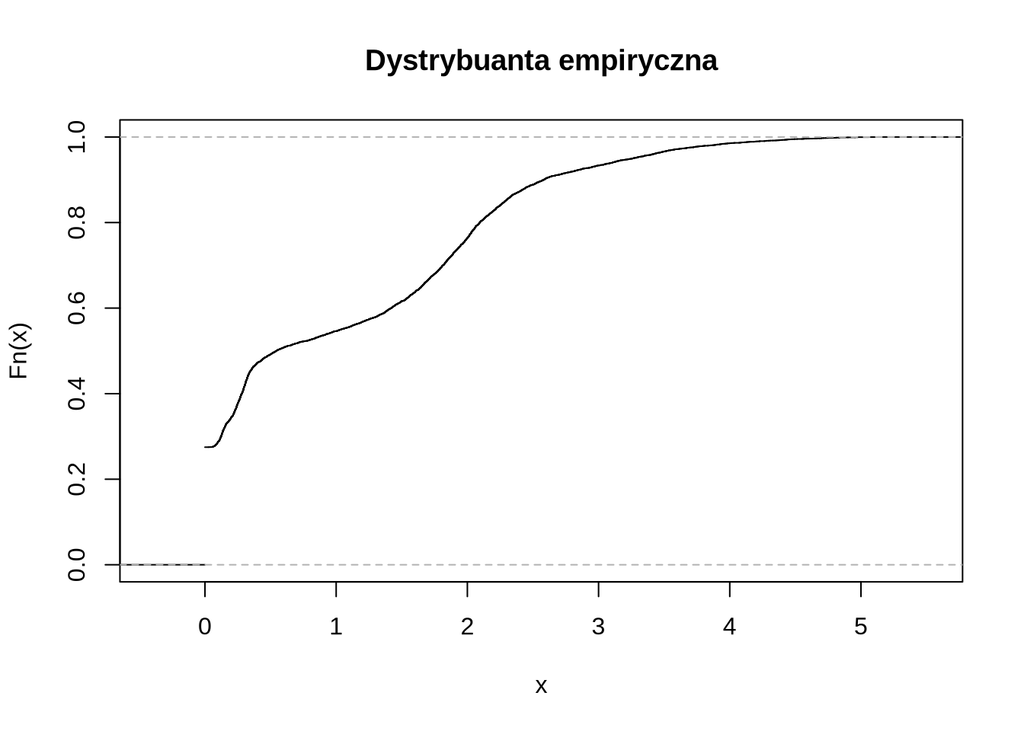

```r
plot(ecdf(train_y$CD36), main='Dystrybuanta empiryczna')
```

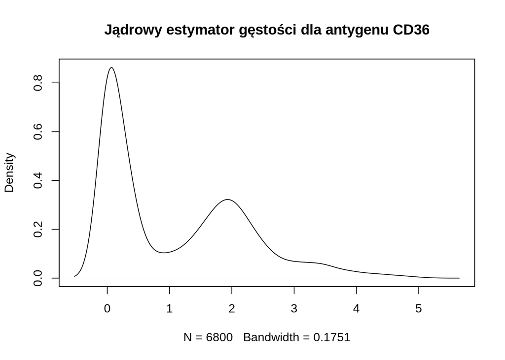

```r
plot(density(train_y$CD36), main='Jądrowy estymator gęstości dla antygenu CD36')
```

```r
length(train_y$CD36[train_y$CD36>0])
```

```
## [1] 4931
```

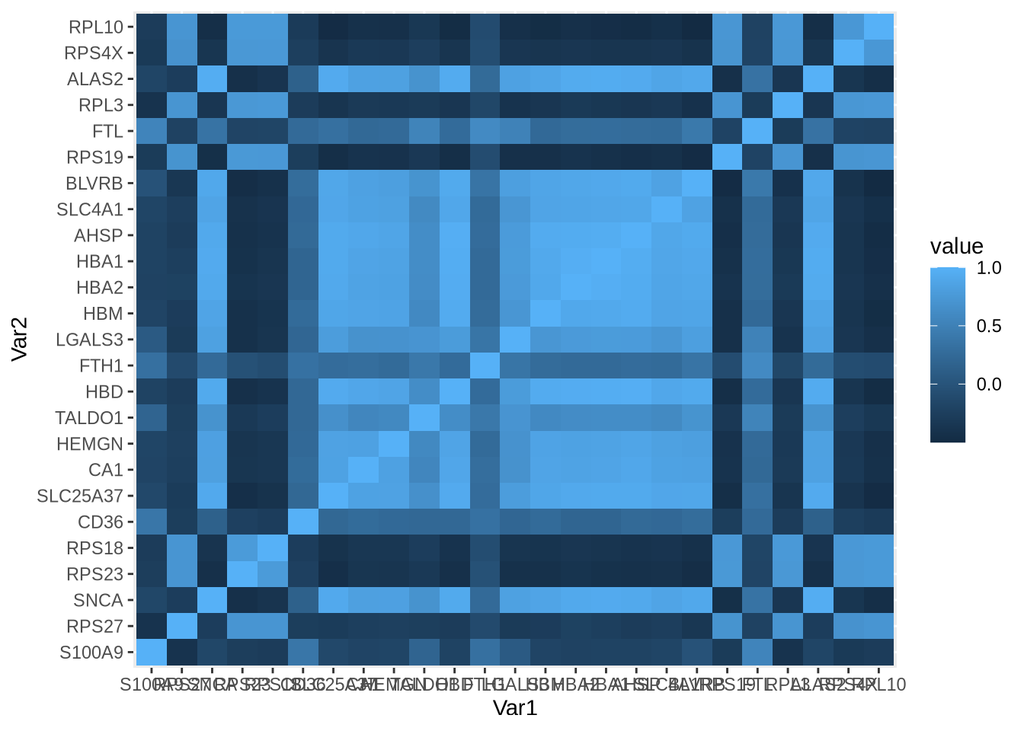

```r
library(dplyr)
not_y <- train_x
y <- train_y$CD36

corelaction <- rep(0, 8999)
for (i in seq(1, length(not_y))){
  corelaction[i] = cor(y, not_y[,i])
}

quant <- quantile(abs(corelaction), (8999-25)/8999)

cor_columns <- c()
for (i in seq_along(colnames(not_y))){
  if (abs(corelaction[i])>(quant)){
    cor_columns <- c(cor_columns, colnames(not_y)[i])
  }
}
library(reshape2)
library(ggplot2)
heatmap_df <- select(train_x, c(cor_columns, CD36))
heatmap_cor_df <- cor(heatmap_df)
heatmap_melt_df <- melt(heatmap_cor_df)
ggplot(data = heatmap_melt_df, aes(x=Var1, y=Var2, fill=value)) +
  geom_tile()
```

### Komentarz do zadania 1:

Dostarczony zbiór treningowy zawiera 6800 obserwacji o 9000 różnych parametrach, z których każdy parametr jest wartością liczbową. Zbiór testowy (X_test) zawiera 1200 obserwacji i 9000 parametrów. Dane treningowe i testowe są kompletne. Najbardziej skorelowaną zmienną ze zmienną objaśnianą jest BLVRB o współczynniku korelacji 0.62

Zmienna objaśniana (CD36) wykazuje średnią ekspresję wynoszącą 1.0862

# Zadanie 2 - Testy statystyczne

## Podpunkt a

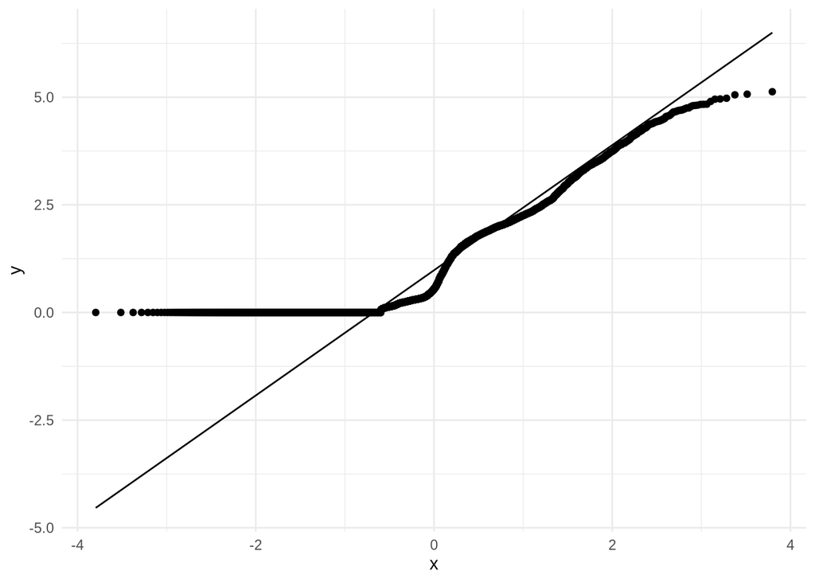

```r
ggplot(train_y, aes(sample=CD36)) +
     stat_qq() +
     stat_qq_line() + theme_minimal()
```

Z powyższego wykresu nie możemy bezpośrednio odczytać średniej, ani wariancji. Jesteśmy natomiast w stanie zauważyć, że mediana ekspresji CD36 w analizowanej tkance jest większa od 0

## Podpunkt b

```r
library(nortest)
ad.test(train_y$CD36)
```

```
##
##  Anderson-Darling normality test
##
## data:  train_y$CD36
## A = 346.99, p-value < 2.2e-16
```

```r
ad.test(train_y$CD36)
```

```
##
##  Anderson-Darling normality test
##
## data:  train_y$CD36
## A = 346.99, p-value < 2.2e-16
```

H0: zmienne pochodzą z rozkładu normalnego  
H1: zmienne nie pochodzą z rozkładu normalnego  
Zdecydowałem o użyciu testu Andersona-Darlinga, jako testu weryfikującego normalność rozkładu, ze względu na dużą liczebność próbki. Zgodnie z przewidywaniami p-wartość pozwala na odrzucenie hipotezy zerowej. Sytuacja taka jest naturalnym wynikiem testowania próbki o tak dużej liczebności z tyloma obserwacjami zerowymi.

## Podpunkt c

```r
colnames(not_y)[which.max(abs(corelaction))]
```

```
## [1] "BLVRB"
```

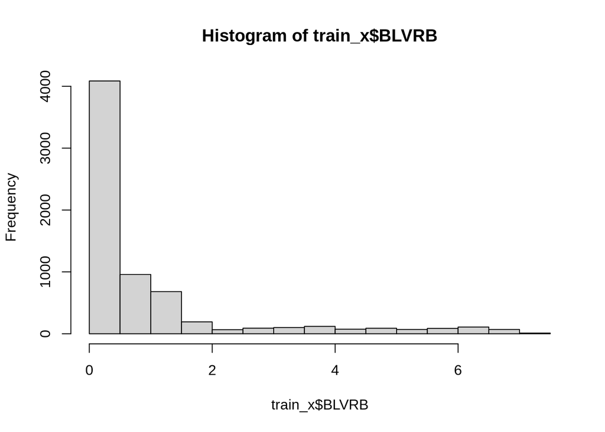

```r
#Zmienna najbardziej skorelowana z CD36 jest BLVRB
hist(train_x$BLVRB)
```

Histogram zmiennej BLVRB wskazuje, że zmienna może pochodzić z rozkładu wykładniczego. Ze względu na znaczną liczebność próbki jestem przekonany, że każdy test da p-value <2.2e-16 jednak, aby to potwierdzić wykonam kilka obliczeń

Wyestymuję wartość parametru lambda funkcją eexp z pakietu EnvStats metodą największej wiarygodności

```r
library(EnvStats)
eexp(train_x$BLVRB, 'mle', ci=T, conf.level = 0.99)
```

```
##
## Results of Distribution Parameter Estimation
## --------------------------------------------
##
## Assumed Distribution:            Exponential
##
## Estimated Parameter(s):          rate = 1.146319
##
## Estimation Method:               mle/mme
##
## Data:                            train_x$BLVRB
##
## Sample Size:                     6800
##
## Confidence Interval for:         rate
##
## Confidence Interval Method:      Exact
##
## Confidence Interval Type:        two-sided
##
## Confidence Level:                99%
##
## Confidence Interval:             LCL = 1.110829
##                                  UCL = 1.182443
```

Wykonam test Kołmogorova-Smirnova dla rozkładu wykładniczego z wyestymowanym parametrem lambda na poziomie istotności 0.01. Test ten jest testem nieparametrycznym, a więc można go zastosować do sprawdzenia zgodności z różnymi rozkładami

```r
ks.test(train_x$BLVRB, 'pexp', 1.146319)
```

```
##
##  Asymptotic one-sample Kolmogorov-Smirnov test
##
## data:  train_x$BLVRB
## D = 0.57544, p-value < 2.2e-16
## alternative hypothesis: two-sided
```

Również testem Kołmogorova-Smirnova sprawdzę, czy zmienna BLVRB ma podobny rozkład w zbiorze testowym i treningowym na poziomie istotności 0.01. Wybrałem test Kołmogorova-Smirnowa, ponieważ jest testem nieparametrycznym i dobrze poradzi sobie z tak różnolicznymi próbami oraz faktem, że w zbiorach jest więcej mierzonych parametrów niż obserwacji (tzw. “small n large p problem”).

H0: Zmienna BLVRB ze zbioru testowego i treningowego pochodzi z tego samego rozkładu  
H1: Zmienna BLVRB ze zbioru testowego i treningowego nie pochodzi z tego samego rozkładu

```r
ks.test(train_x$BLVRB , test_x$BLVRB )
```

```
##
##  Asymptotic two-sample Kolmogorov-Smirnov test
##
## data:  train_x$BLVRB and test_x$BLVRB
## D = 0.032598, p-value = 0.2285
## alternative hypothesis: two-sided
```

Na poziomie istotności 0.01 możemy stwierdzić, że zmienne w zbiorze testowym i treningowym pochodzą z tego samego rozkładu. Jest to bardzo ważna informacja, szczególnie jeśli zbiory te różnią się liczebnością

# Zadanie 3

## Podpunkt a

ElasticNet to model regresji liniowej, który łączy cechy regresji grzbietowej (Ridge Regression) i regresji lasso (Least Absolute Shrinkage and Selection Operator, Lasso). Jest to metoda regularyzacji, która pomaga w radzeniu sobie z problemami nadmiernego dopasowania (overfitting) i wielokolinearności zmiennych w modelach regresji liniowej. Co więcej, dzięki zastosowaniu podwójnej penalizacji nie jest wrażliwa na obserwacje nic nie wnoszące do modelu.

W modelu ElasticNet estymowane są parametry beta, które określają wpływ poszczególnych predyktorów na wartość zmiennej objaśnianej.

Parametry występującego w modelu ElasticNet to alfa i lambda. Parametr alfa określa wpływ regulacji konkretnych typów (L1 lub L2) na model. Jeśli wynosi on 0 to model redukuje się do regresji grzbietowej, natomiast gdy wynosi 1 model jest równoważny z regresją LASSO.  
Parametr lambda określa wartość kary jaka nakładana jest na poszczególne składowe regresji. Dzięki tym parametrom możemy lepiej dopasowywać krzywą do wartości w naszym modelu.

W przypadku trenonowania modelu ElasticNet oraz lasów losowych zdecydowano się na 4-krotną walidację. Jako, że spora część zmiennej objaśnianej (27%) ma wartość zerową chciałem zadbać o to, aby w każdym foldzie znajdowało się wystarczająco dużo wartości niezerowych. Gdybym miał odróżnić komórki z i bez ekspresji CD36 zdecydowałbym się na więcej foldów (klasyfikacja), jednak konieczność estymacji ekspresji białka CD36 (regresja) wymusza branie pod uwagę, aby w foldach nie było zbyt dużo wartości zerowych.

## Podpunkt b

```r
library(glmnet)

X <- as.matrix(train_x)
y <- train_y$CD36

num_rows <- nrow(train_x)
num_subsets <- 4
subset_size <- num_rows / num_subsets
indices <- sample(1:num_rows)
subsets <- split(indices, rep(1:num_subsets, each = subset_size))
alphas <- seq(0,1,by=0.2)

train_model <- function(train_indices, test_indices, alpha) {
  X_train <- X[train_indices, ]
  y_train <- y[train_indices]
  X_test <- X[test_indices, ]
  y_test <- y[test_indices]

  cv_fit <- cv.glmnet(X_train, y_train, alpha = alpha, nfolds = 4)

  predictions <- predict(cv_fit, X_test, s = "lambda.min")
  train_predictions <- predict(cv_fit, X_train, s = "lambda.min")

  test_mse <- mean((predictions - y_test)^2, na.rm = TRUE)
  train_mse <- mean((train_predictions - y_train)^2, na.rm = TRUE)

  list(cv_fit = cv_fit, predictions = predictions, test_indices = test_indices,
       test_mse = test_mse, train_mse = train_mse, alpha = alpha)
}

results <- list()
result_counter <- 1
for (i in 1:num_subsets) {
  test_indices <- subsets[[i]]
  train_indices <- unlist(subsets[-i])
  for (alpha in alphas) {
    results[[result_counter]] <- train_model(train_indices, test_indices, alpha)
    result_counter <- result_counter + 1
  }
}

mse_values <- list()
test_mse_list <- numeric(length(results))
train_mse_list <- numeric(length(results))

for (i in 1:length(results)) {
  cv_fit <- results[[i]]$cv_fit
  mse_fold <- cv_fit$cvm
  lambdas_fold <- cv_fit$lambda.min
  mse_data <- data.frame(
    lambda = lambdas_fold,
    mse = mse_fold,
    fold = rep((i - 1) %/% length(alphas) + 1, length(mse_fold)),
    alpha = rep(results[[i]]$alpha, length(mse_fold))
  )
  mse_values[[i]] <- mse_data

  test_mse_list[i] <- results[[i]]$test_mse
  train_mse_list[i] <- results[[i]]$train_mse
}

mse_df <- do.call(rbind, mse_values)
```

## Podpunkt c

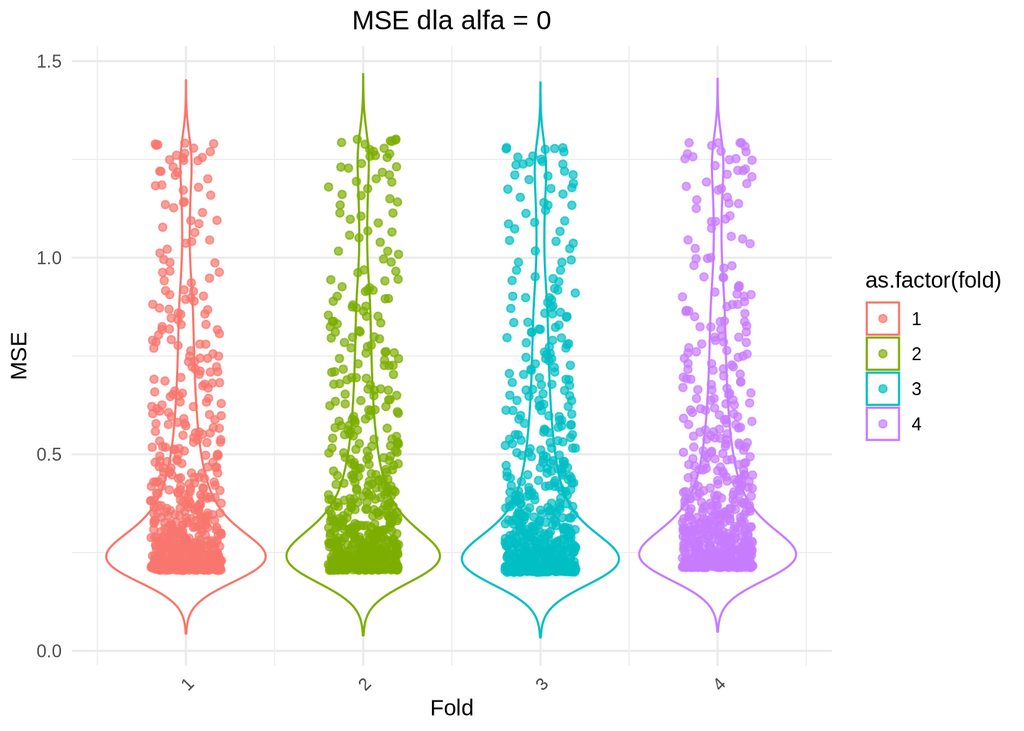

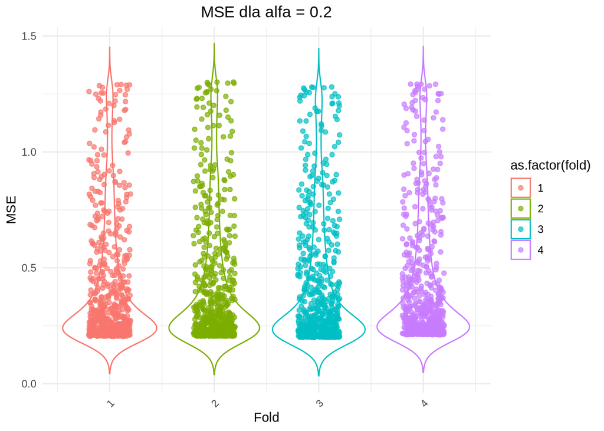

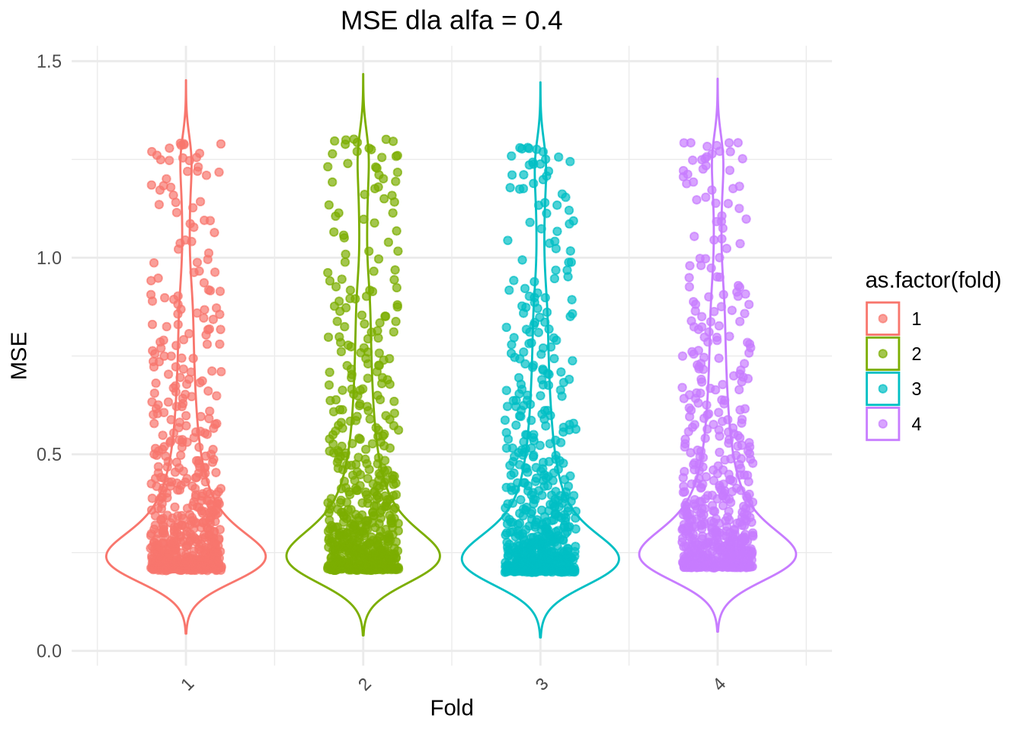

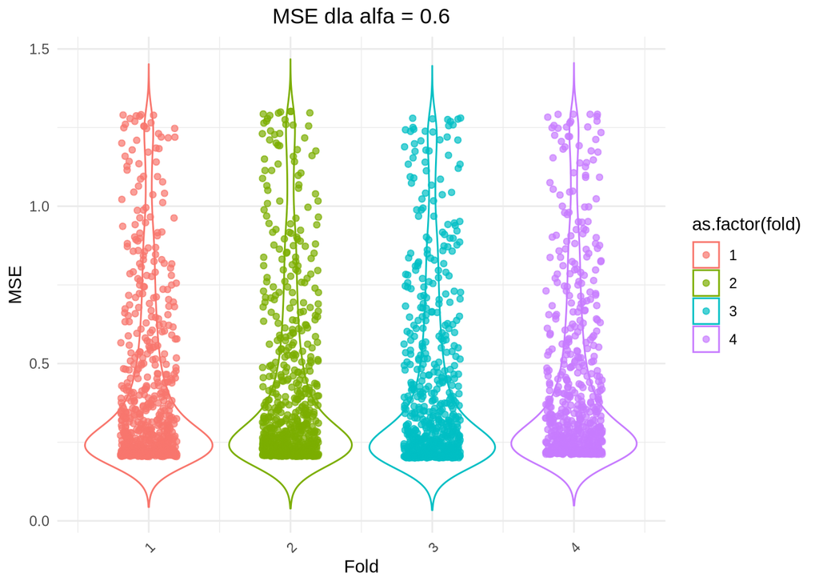

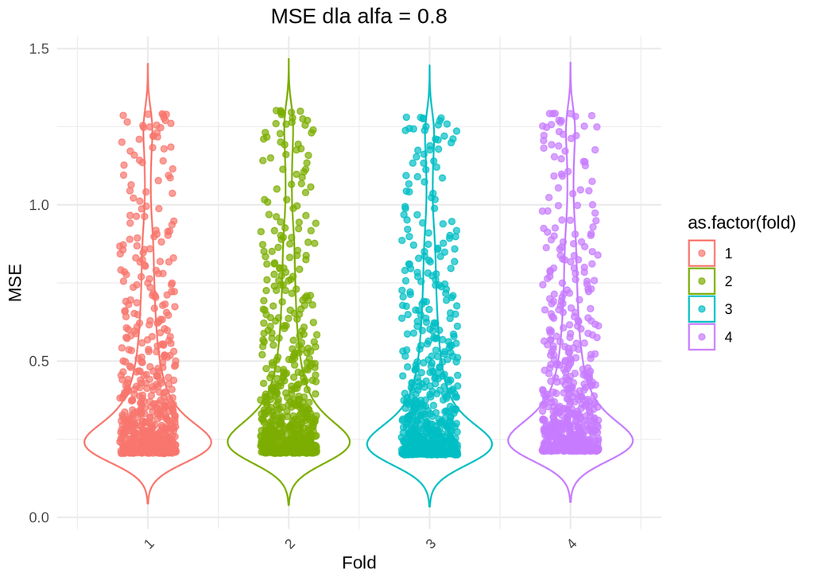

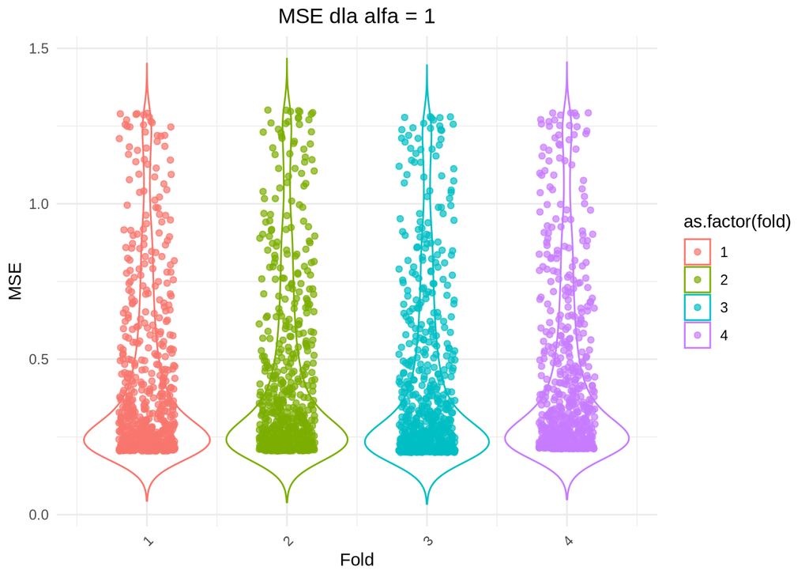

```r
for (alpha in alphas) {
  alpha_df <- subset(mse_df, alpha == alpha)

  p <- ggplot(alpha_df, aes(x = fold , y = mse, color=as.factor(fold))) +
    geom_violin(trim = FALSE) +
    geom_jitter(width = 0.2, size = 1.5, alpha = 0.7) +
    labs(
      title = paste("MSE dla alfa =", alpha),
      x = "Fold",
      y = "MSE"
    ) +
    theme_minimal() +
    theme(
      plot.title = element_text(hjust = 0.5),
      axis.text.x = element_text(angle = 45, hjust = 1)
    )

  print(p)
}
```

## Podpunkt d

```r
best_index <- which.min(test_mse_list)
best_alpha <- results[[best_index]]$alpha
best_lambda <- results[[best_index]]$cv_fit$lambda.min
best_train_mse <- train_mse_list[best_index]
best_test_mse <- test_mse_list[best_index]

cat("Najlepsza kombinacja hiperparametrów:\n")
```

```
## Najlepsza kombinacja hiperparametrów:
```

```r
cat("Alpha:", best_alpha, "\n")
```

```
## Alpha: 0.8
```

```r
cat("Lambda:", best_lambda, "\n")
```

```
## Lambda: 0.01331322
```

```r
cat("Średni błąd treningowy:", best_train_mse, "\n")
```

```
## Średni błąd treningowy: 0.1368754
```

```r
cat("Średni błąd walidacyjny:", best_test_mse, "\n")
```

```
## Średni błąd walidacyjny: 0.1804365
```

# Zadanie 4

## Podpunkt a

Do budowy lasu losowego zdecydowałem się wykorzystać trzy hiperparametry:

### 1. mtry - Liczba zmiennych rozważanych przy każdym podziale

Zdecydowano się na wartości 60 i 90. Wartość 90 to w przybliżeniu pierwiastek z liczby zmiennych, która dobrze sprawdzi się w przypadku, kiedy dane będą dobrze separowalne liniowo i przypadek ten będzie bardziej regresją, niż klasyfikacją Wartość 60 będzie wskazywała, że przypadek jest jednak bardziej problemem klasyfikacyjnym.

### 2. ntree - Liczba drzew w lesie

Im większy parametr ntree tym możliwa większa stabilność modelu. W naszym przypadku bardzo dużych danych zdecydowano się na wybór względnie dużych wartości (200 i 300).

### 3. nodesize - Minimalna liczba próbek w węźle

W przypadku dużych modeli mały parametr nodesize szczególnie mocno może prowadzić do przetrenowania. Z tego powodu zdecydowano się na wybór hiperparametrów tj. 5 i 10, dzięki czemu unikniemy małych węzłów i zwiększymy plastyczność modelu.

```r
library(randomForest)
tune_grid <- expand.grid(
  mtry = c(60, 90),
  ntree = c(200, 300),
  nodesize = c(5, 10)
)

train_rf_model <- function(train_indices, test_indices, tune_grid) {
  X_train <- X[train_indices, ]
  y_train <- y[train_indices]
  X_test <- X[test_indices, ]
  y_test <- y[test_indices]

  results <- list()

  for (i in 1:nrow(tune_grid)) {
    params <- tune_grid[i, ]

    rf_model <- randomForest(
      x = X_train, y = y_train,
      mtry = params$mtry,
      ntree = params$ntree,
      nodesize = params$nodesize
    )

    predictions <- predict(rf_model, X_test)
    mse <- mean((y_test - predictions)^2)

    train_predictions <- predict(rf_model, X_train)
    train_mse <- mean((y_train - train_predictions)^2)

    result <- list(
      mtry = params$mtry,
      ntree = params$ntree,
      nodesize = params$nodesize,
      mse = mse,
      train_mse = train_mse
    )

    results[[i]] <- result
  }

  return(results)
}
results_rf <- list()

for (i in 1:num_subsets) {
  test_indices <- subsets[[i]]
  train_indices <- unlist(subsets[-i])

  result <- train_rf_model(train_indices, test_indices, tune_grid)
  results_rf[[i]] <- result
  cat('Wytrenowano drzewo nr', i, '\n')
}
```

```
## Wytrenowano drzewo nr 1
## Wytrenowano drzewo nr 2
## Wytrenowano drzewo nr 3
## Wytrenowano drzewo nr 4
```

```r
mse_values <- data.frame()

for (i in 1:length(results_rf)) {
  fold_results <- results_rf[[i]]

  for (j in 1:length(fold_results)) {
    mse_data <- data.frame(
      mtry = fold_results[[j]]$mtry,
      ntree = fold_results[[j]]$ntree,
      nodesize = fold_results[[j]]$nodesize,
      mse = fold_results[[j]]$mse,
      train_mse = fold_results[[j]]$train_mse,
      fold = i
    )
    mse_values <- rbind(mse_values, mse_data)
  }
}

mse_values$combination <- with(mse_values, paste(mtry, ntree, nodesize, sep = "-"))
```

## Podpunkt b

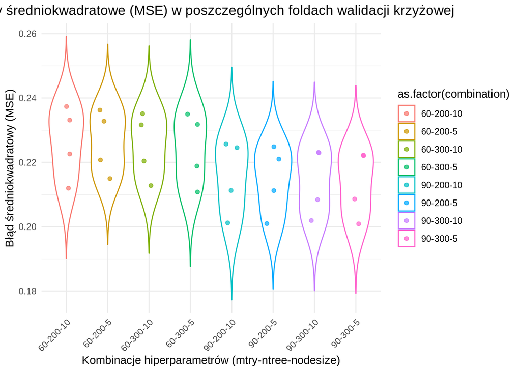

```r
# Tworzenie wykresu skrzypcowego
p <- ggplot(mse_values, aes(x = combination, y = mse, color = as.factor(combination))) +
  labs(
    title = "Błędy średniokwadratowe (MSE) w poszczególnych foldach walidacji krzyżowej",
    x = "Kombinacje hiperparametrów (mtry-ntree-nodesize)",
    y = "Błąd średniokwadratowy (MSE)",
    fill = "Fold"
  ) +
  geom_violin(trim = FALSE) +
  geom_jitter(width = 0.2, size = 1.5, alpha = 0.7) +
  theme_minimal() +
  theme(
    plot.title = element_text(hjust = 0.5),
    axis.text.x = element_text(angle = 45, hjust = 1)
  )
print(p)
```

## Podpunkt c

```r
best_combination <- mse_values %>%
  group_by(combination) %>%
  summarise(mean_mse = mean(mse)) %>%
  arrange(mean_mse) %>%
  slice(1) %>%
  pull(combination)

best_results <- mse_values[mse_values$combination == best_combination, ]

mean_train_mse <- mean(best_results$train_mse)
mean_test_mse <- mean(best_results$mse)

cat("Najlepsza kombinacja hiperparametrów: ", best_combination, "\n")
```

```
## Najlepsza kombinacja hiperparametrów:  90-300-5
```

```r
cat("Średni błąd treningowy: ", mean_train_mse, "\n")
```

```
## Średni błąd treningowy:  0.03490812
```

```r
cat("Średni błąd walidacyjny: ", mean_test_mse, "\n")
```

```
## Średni błąd walidacyjny:  0.2134529
```

# Zadanie 5

```r
calculate_baseline_model <- function(train_indices, test_indices) {
  y_train <- y[train_indices]
  y_test <- y[test_indices]

  baseline_prediction_train <- mean(y_train)
  baseline_prediction_test <- baseline_prediction_train

  train_mse <- mean((y_train - baseline_prediction_train)^2)
  test_mse <- mean((y_test - baseline_prediction_test)^2)

  return(list(train_mse = train_mse, test_mse = test_mse))
}

baseline_errors <- data.frame(fold = integer(), train_mse = numeric(), test_mse = numeric())

for (i in 1:num_subsets) {
  test_indices <- subsets[[i]]
  train_indices <- unlist(subsets[-i])

  baseline_error <- calculate_baseline_model(train_indices, test_indices)
  baseline_errors <- rbind(baseline_errors, data.frame(fold = i, train_mse = baseline_error$train_mse, test_mse = baseline_error$test_mse))
}

mean_train_mse <- mean(baseline_errors$train_mse)
mean_test_mse <- mean(baseline_errors$test_mse)

cat("Średni błąd treningowy (MSE) modelu referencyjnego:", mean_train_mse, "\n")
```

```
## Średni błąd treningowy (MSE) modelu referencyjnego: 1.291963
```

```r
cat("Średni błąd walidacyjny (MSE) modelu referencyjnego:", mean_test_mse, "\n")
```

```
## Średni błąd walidacyjny (MSE) modelu referencyjnego: 1.292099
```

[output not shown]

# Komentarz do zadania 5

Oba wytrenowane modele osiągają o wiele lepsze wyniki niż model referencyjny. W przypadku modelu lasów losowych doszło najprawdopodobniej do przetrenowania, przez co błąd walidacyjny jest większy niż w modelu ElasticNet. Model ElasticNet lepiej poradził sobie z dużą liczbą danych, z których tak naprawdę niewiele miało realny wpływ na poziom białka CD36. Jakkolwiek biologia ekspresji genów jest skomplikowana tak jednak można być pewnym, że znaczna część pomiarów nie wnosiła dużo informacji o modelu. Ten aspekt jest możliwym powodem złego wytrenowania lasów losowych. W drzewach było zbyt mało cech, które były znaczące, przez co cechy nieznaczące były odbierane jako istotne (tzw. przetrenowanie wynikające z modelowania szumu, które było poruszane na wykładzie). Model ElasticNet może nie brać pod uwagę nieznaczące obserwacje, dzięki regulacji L1, która związana jest z regresją LASSO. Argument, który przemawia, ku temu jest taki, że najlepsza wyestymowana alfa wynosi 0.8, a więc jest znacznie bliższa do 1, która odpowiada regresji LASSO.